# Samusik data and LLM data mishmash test

Tyler Burns

February 27, 2026

[Home](https://tjburns08.github.io/)

*Imagine a universe entirely without structure, without shape, without connections. A cloud of microscopic events, like fragments of space-time … except that there is no space or time. What characterizes one point in space, for one instant? Just the values of the fundamental particle fields, just a handful of numbers. Now, take away all notions of position, arrangement, order, and what’s left? A cloud of random numbers.*

*But if the pattern that is me could pick itself out from all the other events taking place on this planet, why shouldn’t the pattern we think of as ‘the universe’ assemble itself, find itself, in exactly the same way? If I can piece together my own coherent space and time from data scattered so widely that it might as well be part of some giant cloud of random numbers, then what makes you think that you’re not doing the very same thing?*

Greg Egan, *Permutation City*

## 0.1 Introduction

Here, we are going to take the Samusik dataset and the LLM generated data and merge them together, then process them and make our UMAP. We will then color by from where the data came.

So we can be clear about how the LLM-generated data came about, we will be explicit about how it was done. The LLM being used was Claude Sonnet 4.6, a frontier model at the time of the experiment. This was accessed through OpenRouter, where the prompt of simulating one cell from the Samusik dataset was run over and over again for a set number of times.

Below is the script (which was not run directly as part of this markdown). Note that in order to use this script, I set up a “chatbot” tool that is accessible through the command line. I show you how to do this [here](https://tjburns08.github.io/command_line_writeup.html).

```bash
num_runs=1000; # However many you want
prompt="Please simulate one cell in the flagship Samusik CyTOF dataset. Make the data raw. Use floating points as you'd do in a fcs file. I'll do the asinh transform later. I would like you to output as follows.

Here are the names of the parameters: Time, Cell_length, BC1, BC2, BC3, BC4, BC5, BC6, Ter119, CD45.2, Ly6G, IgD, CD11c, F480, CD3, NKp46, CD23, CD34, CD115, CD19, 120g8, CD8, Ly6C, CD4, CD11b, CD27, CD16_32, SiglecF, Foxp3, B220, CD5, FceR1a, TCRgd, CCR7, Sca1, CD49b, cKit, CD150, CD25, TCRb, CD43, CD64, CD138, CD103, IgM, CD44, MHCII, DNA1, DNA2, Cisplatin, beadDist

You will create the numbers for these parameters. Your output will just be the numbers comma separated. No names, but the nmbers will be outputted in the order of the markers that we specified above, from Time to beadDist.

Just output this. No other commentary";

for i in $(seq 1 $num_runs);
do
    chatbot "claude" "$prompt" >> output.txt;
done
```

## 0.2 Process data

```r
library(tidyverse)
suppressPackageStartupMessages(library(here))
setwd(here("..", "data"))

num_cells <- 10000
sam <- readr::read_rds("samusik_01.rds") %>% as_tibble()
sam <- sam[sample(nrow(sam), num_cells),]

sam$dataset <- "samusik"
```

Now we get out our LLM results.

```r
setwd(here("..", "local_data"))

# Read in the file
llm <- readr::read_lines("output.txt")

# Tidy
llm <- lapply(llm, function(i) stringr::str_split(i, ",")[[1]] %>% as.numeric()) %>%
  do.call(rbind, .) %>%
  as_tibble()

names(llm) <- names(sam)
llm$dataset <- "llm"
```

And now for the mishmash

```r
cells <- bind_rows(sam, llm)
cells
```

```
## # A tibble: 11,058 × 52
##        Time Cell_length   BC1   BC2   BC3   BC4    BC5    BC6  Ter119 CD45.2  Ly6G     IgD  CD11c    F480
##       <dbl>       <dbl> <dbl> <dbl> <dbl> <dbl>  <dbl>  <dbl>   <dbl>  <dbl> <dbl>   <dbl>  <dbl>   <dbl>
##  1 15759407          26  119. 120.   148. 20.3   4.65   4.90   0.0743  11.0  6.74  -0.490  -0.160  2.14
##  2 15147226          31  277. 215.   198. 26.1  10.6   13.1    1.45     6.34 0.682 -0.293  -0.483  2.17
##  3  8744261          27  217. 122.   173. 12.4   4.50   2.66  -0.0842   1.98 2.83   3.47    0.973  7.47
##  4 10813638          23  157.  76.3  185.  5.34 -0.769  0.830 -0.790   11.3  0.931 11.9    -0.626  3.36
##  5  6158528          22  351. 235.   348. 27.8   2.26  -0.790 -0.136   23.5  2.34  -0.0344 10.1    3.78
##  6    62586          22  232. 159.   226.  6.82 -0.750 16.4    0.729    1.75 0.949  0.462  -0.207  0.289
##  7 11326926          20  181. 180.   208.  5.64 -0.356 -0.432 -0.275   15.0  7.74  29.0     2.54  -0.0184
##  8 12518957          20  238. 119.   261.  6.96  4.86   1.22  -0.468    3.45 0.779 -0.539  -0.427  0.183
##  9  7734188          21  204. 163.   176. 10.7  27.7    4.31  -0.0458   9.29 9.99  -0.671  -0.247 48.4
## 10  4988147          33  344. 183.   287. 27.2  30.6   13.2   -0.484   41.0  8.70  -0.0902 -0.673 14.7
## # ℹ 11,048 more rows
## # ℹ 38 more variables: CD3 <dbl>, NKp46 <dbl>, CD23 <dbl>, CD34 <dbl>, CD115 <dbl>, CD19 <dbl>,
## #   `120g8` <dbl>, CD8 <dbl>, Ly6C <dbl>, CD4 <dbl>, CD11b <dbl>, CD27 <dbl>, CD16_32 <dbl>,
## #   SiglecF <dbl>, Foxp3 <dbl>, B220 <dbl>, CD5 <dbl>, FceR1a <dbl>, TCRgd <dbl>, CCR7 <dbl>, Sca1 <dbl>,
## #   CD49b <dbl>, cKit <dbl>, CD150 <dbl>, CD25 <dbl>, TCRb <dbl>, CD43 <dbl>, CD64 <dbl>, CD138 <dbl>,
## #   CD103 <dbl>, IgM <dbl>, CD44 <dbl>, MHCII <dbl>, DNA1 <dbl>, DNA2 <dbl>, Cisplatin <dbl>,
## #   beadDist <dbl>, dataset <chr>
```

From here, we do our pre-processing. Do we remember what the surface markers are for the Samusik dataset?

```r
setwd(here("..", "local_data"))
md <- readr::read_rds("marker_types.rds")
type_markers <- dplyr::filter(md, marker_class == "type")$marker_name

surface <- cells[type_markers]
surface
```

```
## # A tibble: 11,058 × 39
##     Ter119 CD45.2  Ly6G     IgD  CD11c    F480     CD3  NKp46    CD23    CD34  CD115     CD19  `120g8`
##      <dbl>  <dbl> <dbl>   <dbl>  <dbl>   <dbl>   <dbl>  <dbl>   <dbl>   <dbl>  <dbl>    <dbl>    <dbl>
##  1  0.0743  11.0  6.74  -0.490  -0.160  2.14   -0.783  -0.118 -0.581   0.728  12.0    0.826    -0.394
##  2  1.45     6.34 0.682 -0.293  -0.483  2.17   -0.141  -0.767 -0.130  -0.756   0.427 -0.489     0.858
##  3 -0.0842   1.98 2.83   3.47    0.973  7.47    0.389   2.95   0.794   8.51   56.4    6.20     -0.249
##  4 -0.790   11.3  0.931 11.9    -0.626  3.36   -0.617   0.688  1.08   -0.0823 11.2   -0.776    -0.772
##  5 -0.136   23.5  2.34  -0.0344 10.1    3.78   -0.234   1.90   0.556   3.97    1.71   0.621   249.
##  6  0.729    1.75 0.949  0.462  -0.207  0.289  -0.601  -0.361 -0.747   0.741   1.87  -0.00809  -0.198
##  7 -0.275   15.0  7.74  29.0     2.54  -0.0184  3.87    7.17  -0.0965 -0.514   0.808  7.44     -0.712
##  8 -0.468    3.45 0.779 -0.539  -0.427  0.183  -0.646   0.711 -0.818  21.9     1.32  -0.622    -0.0216
##  9 -0.0458   9.29 9.99  -0.671  -0.247 48.4     0.0843  1.98  -0.505   4.58    4.08  -0.543    -0.178
## 10 -0.484   41.0  8.70  -0.0902 -0.673 14.7     0.257  -0.698 -0.588   4.41   -0.752 -0.120    -0.214
## # ℹ 11,048 more rows
## # ℹ 26 more variables: CD8 <dbl>, Ly6C <dbl>, CD4 <dbl>, CD11b <dbl>, CD27 <dbl>, CD16_32 <dbl>,
## #   SiglecF <dbl>, Foxp3 <dbl>, B220 <dbl>, CD5 <dbl>, FceR1a <dbl>, TCRgd <dbl>, CCR7 <dbl>, Sca1 <dbl>,
## #   CD49b <dbl>, cKit <dbl>, CD150 <dbl>, CD25 <dbl>, TCRb <dbl>, CD43 <dbl>, CD64 <dbl>, CD138 <dbl>,
## #   CD103 <dbl>, IgM <dbl>, CD44 <dbl>, MHCII <dbl>
```

## 0.3 Visualize results

And from here, we are going to make a UMAP

```r
library(umap)

dimr <- umap(surface)$layout %>% as_tibble()
names(dimr) <- c("umap1", "umap2")
```

And from here, we are going to plot it as such:

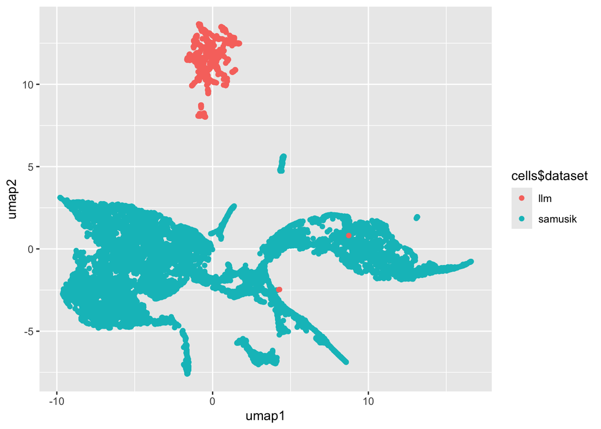

```r
library(ggplot2)
ggplot(dimr, aes(x = umap1, y = umap2, color = cells$dataset)) +
  geom_point()
```

## 0.4 Discussion

Here, we find that the LLM generated data were not in-line with the actual Samusik data. You can see that in the UMAP, the LLM generated data primarily formed a separate island. This suggests that not only did the LLM not “rip” the data, but also it could not approximate the data convincingly, with the prompt at hand.

We note that the use of an agentic system like Claude Code would likely lead to the generation of a script that would literally simulate data from the distributions of the Samusik dataset, which it would pull. But here, we were concerned primarily with the question of to what extent the Samusik dataset was sitting in the LLM’s “latent space.”

Additional prompt engineering may well lead to better approximated data. This first pass was an attempt to see what would happen with minimal instructions beyond “simulate a cell.” But if we were to be more explicit with the instructions, in terms of what it means to simulate a cell (pull from the marker distributions that are expected given you training data around all things CyTOF…) then maybe we would get more convincing simulated data (by this metric, data that line up with the Samusik dataset on the UMAP above, though there are more precise metrics we can use down the line).

We also note that the Samusik dataset is a hard dataset to start with. Perhaps taking a step back and trying with PBMCs might lead to more success here. This is because there is likely more PBMC data in the LLM’s training data, as compared to mouse bone marrow. But this is yet to be determined.